# ALL Imagenet Models

## Large Models

url : https://www.analyticsvidhya.com/blog/2020/08/top-4-pre-trained-models-for-image-classification-with-python-code/

VGG-16  
ResNet50  
Inceptionv3  
EfficientNet

## Smaller Models

url : https://machinethink.net/blog/mobile-architectures/

**Older Architecture**

SqueezeNet  
MobileNet v1  
MobileNet v2

**New Architecture**  
MnasNet  
MobileNet v3  
BlazeFace  
TinyYOLO / Darknet  
SqueezeNext  
ShuffleNet  
CondenseNet  
ESPNet  
DiCENet  
FBNet & ChamNet  
GhostNet  
MixNet  
EfficientNet

```python
import numpy as np
import os
import cv2
import pandas as pd
import matplotlib.pyplot as plt
import json
import random
import sys
import glob
import tensorflow as tf

from tensorflow.keras.layers import *
from tensorflow.keras.models import Model
from tensorflow.keras.applications import MobileNetV2
tf.__version__
```

```
'2.5.0'
```

### Squeeze Net v1.1 (2016)

uses only smaller 1by1 and 3by3 sized filter  
Main building block : Fire Module .

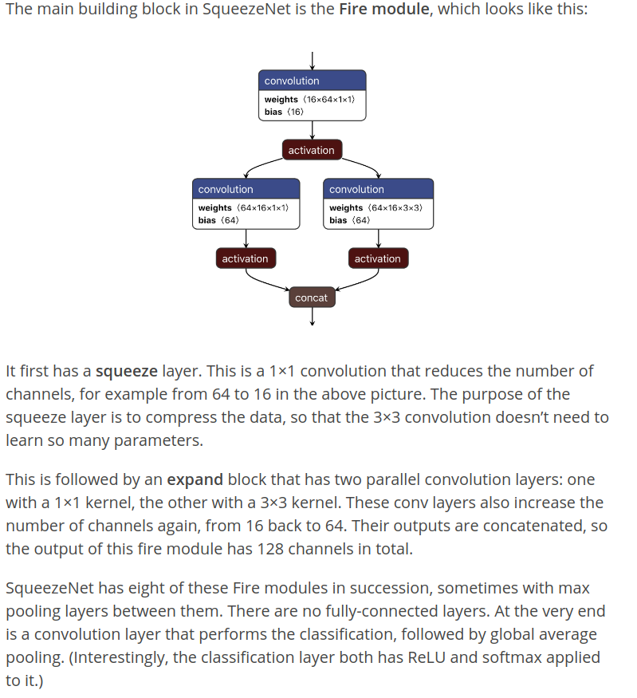

```python
def squeeze_layer(inp_tensor):
  x = Conv2D(16, (1,1), activation="relu", padding="same")(inp_tensor)
  x1 = Conv2D(64, (1,1), activation="relu", padding="same")(x)
  x2 = Conv2D(64, (3,3), activation="relu", padding="same")(x)
  x = Concatenate()([x1 ,  x2])
  return x
```

```python
inp_tensor = Input(shape = (32 , 32 , 64))
result = squeeze_layer(inp_tensor)
model = Model(inputs = inp_tensor , outputs = result)
model.summary()
```

```
Model: "model"
__________________________________________________________________________________________________
Layer (type)                    Output Shape         Param #     Connected to
==================================================================================================
input_1 (InputLayer)            [(None, 32, 32, 64)] 0
__________________________________________________________________________________________________
conv2d (Conv2D)                 (None, 32, 32, 16)   1040        input_1[0][0]
__________________________________________________________________________________________________
conv2d_1 (Conv2D)               (None, 32, 32, 64)   1088        conv2d[0][0]
__________________________________________________________________________________________________
conv2d_2 (Conv2D)               (None, 32, 32, 64)   9280        conv2d[0][0]
__________________________________________________________________________________________________
concatenate (Concatenate)       (None, 32, 32, 128)  0           conv2d_1[0][0]
                                                                 conv2d_2[0][0]
==================================================================================================
Total params: 11,408
Trainable params: 11,408
Non-trainable params: 0
__________________________________________________________________________________________________
```

[figure not shown]

```python
tf.keras.utils.plot_model(
    model, to_file='tmp.png', show_shapes=True,
    show_layer_names=True, rankdir='LR', expand_nested=False, dpi=96
)
```

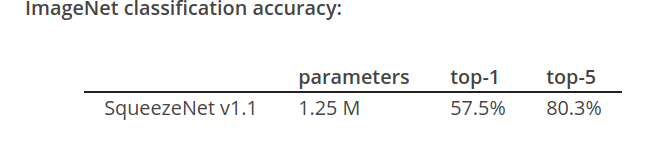

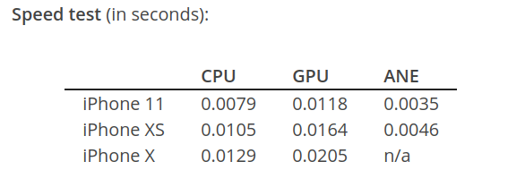

## DepthWise Convolution -> Pointwise convolution

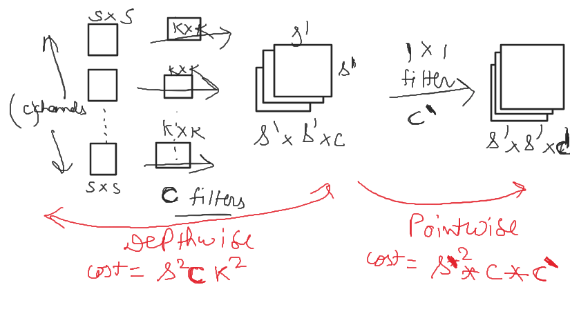

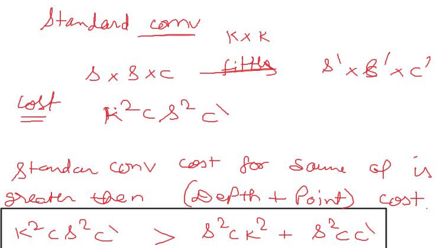

**cost == no of operations (additions and multiplications)**  
**Learnable paramters in Dept + Point op = c*k*k + c*c' , which is less than standard conv parameters ( k*k*c*c') , hence reduction in accuracy .**  
**Note : reducing kernel size reduces the receptive field size as well hence , might require larger network to achieve simillar effect.**

## Fused Batch Norm vs Batch Norm :

Fused batch norm basically fuses the batch norm operation with a conv layer to gain in speed. Thus, we can replace these two layers by a single convolutional layer with the following parameters: $$ filter weights: \mathbf{W}=\mathbf{W}_{BN}\cdot \mathbf{W}_{conv} ;$$ $$bias: \mathbf{b}=\mathbf{W}_{BN}.\mathbf{b}_ {conv}+\mathbf{b}_{BN}$$

## Mobilenet -v1 2017

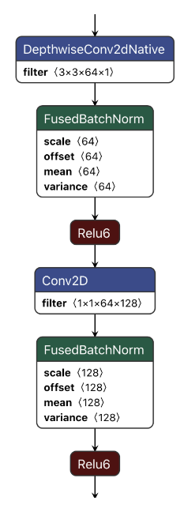

MobileNet v1 consists of 13 of these blocks in a row. It does not use max pooling to reduce the spatial dimensions, but some of the depthwise layers have stride 2. At the end is a global average pooling layer followed by a fully-connected layer or a 1×1 convolution for doing the classification .  
MobileNet has a hyperparameter called the depth multipler (confusingly, also named the “width” multiplier) that lets you choose how many channels are used by the convolution layers. You use this to directly increase or decrease the number of learned parameters. Here, I’ve assumed a depth multiplier of 1.0.

If you use a larger multiplier, the model will give better results but it will also use more parameters and therefore be slower. Conversely, a smaller multiplier makes the model faster but gives worse results.

For example, with multiplier 0.5, MobileNet has 1.34M parameters, which is similar to SqueezeNet. It also runs at roughly the same speed, but has a higher accuracy of 63.3% (top-1).

```python
def mob1_layer():
  model = tf.keras.Sequential()
  model.add(Input(shape = (32 , 32 , 64)))
  model.add(DepthwiseConv2D((3,3) , padding = 'same'))
  model.add(BatchNormalization())
  model.add(ReLU(max_value = 6))
  model.add(Conv2D(128 , (1,1)))
  model.add(BatchNormalization())
  model.add(ReLU(max_value = 6))

  return model
```

```python
model = mob1_layer()
model.summary()
```

```
WARNING:tensorflow:Please add `keras.layers.InputLayer` instead of `keras.Input` to Sequential model. `keras.Input` is intended to be used by Functional model.
Model: "sequential_3"
_________________________________________________________________
Layer (type)                 Output Shape              Param #
=================================================================
depthwise_conv2d_2 (Depthwis (None, 32, 32, 64)        640
_________________________________________________________________
batch_normalization_6 (Batch (None, 32, 32, 64)        256
_________________________________________________________________
re_lu_6 (ReLU)               (None, 32, 32, 64)        0
_________________________________________________________________
conv2d_6 (Conv2D)            (None, 32, 32, 128)       8320
_________________________________________________________________
batch_normalization_7 (Batch (None, 32, 32, 128)       512
_________________________________________________________________
re_lu_7 (ReLU)               (None, 32, 32, 128)       0
=================================================================
Total params: 9,728
Trainable params: 9,344
Non-trainable params: 384
_________________________________________________________________
```

```python
tf.keras.utils.plot_model(
    model, to_file='tmp.png', show_shapes=True,
    show_layer_names=True, rankdir='LR', expand_nested=False, dpi=96
)
```

[figure not shown]

## Mobilenet v2 - 2018

The idea: Like v1, use depthwise convolutions, but rearrange them . The depthwise convolution is now in the middle. Before the depthwise layer is a 1×1 convolution known as the expansion layer. This increases the number of channels. After the depthwise layer is another 1×1 convolution that reduces the number of channels again, known as the projection layer or the bottleneck layer.

When the number of channels going into the block is the same as the number of channels coming out (64 in the above picture), there is also a residual connection. Just like in ResNet, this helps to improve the flow of gradients during the backwards pass.

The authors of MobileNet v2 call this an inverted residual because it goes between the bottleneck layers, which have only a small number of channels. Whereas a normal residual connection from ResNet goes between layers that have many channels.

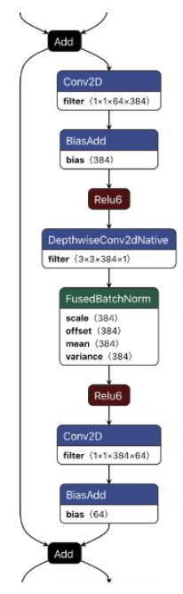

The full MobileNet v2 architecture consists of 17 of these building blocks in a row. This is followed by a regular 1×1 convolution, a global average pooling layer, and a classification layer.

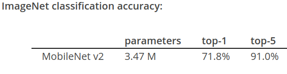

Even though it uses fewer parameters, MobileNet v2 does not run massively faster than v1 and sometimes can even be slower. One explanation is that v2 has more layers, but this also seems to be a Core ML issue. When implemented using Metal Performance Shaders, v2 is definitely a lot faster.

As with v1, you can use the depth multiplier hyperparameter to determine how many channels are used by the model’s convolution layers. For example, with a multiplier of 1.4, the top-1 accuracy improves to 75.0%. With a multiplier of 0.75, the top-1 accuracy drops to 69.8%. (The measurements in table were taken with multiplier 1.0.)

```python
def mob2_layer():
  model = tf.keras.Sequential()
  model.add(Input(shape = (32 , 32 , 64)))
  # expansin layer  ===========
  model.add(Conv2D(128 , (1,1)))
  model.add(ReLU(max_value = 6))
  # ============================
  model.add(DepthwiseConv2D((3,3) , padding = 'same'))
  model.add(BatchNormalization())
  model.add(ReLU(max_value = 6))
  # bottleneck or projection layer
  model.add(Conv2D(64 , (1,1)))
  model.add(ReLU(max_value = 6))
  # ===========================
  return model
```

```python
model = mob2_layer()
model.summary()
```

```
WARNING:tensorflow:Please add `keras.layers.InputLayer` instead of `keras.Input` to Sequential model. `keras.Input` is intended to be used by Functional model.
Model: "sequential_4"
_________________________________________________________________
Layer (type)                 Output Shape              Param #
=================================================================
conv2d_7 (Conv2D)            (None, 32, 32, 128)       8320
_________________________________________________________________
re_lu_8 (ReLU)               (None, 32, 32, 128)       0
_________________________________________________________________
depthwise_conv2d_3 (Depthwis (None, 32, 32, 128)       1280
_________________________________________________________________
batch_normalization_8 (Batch (None, 32, 32, 128)       512
_________________________________________________________________
re_lu_9 (ReLU)               (None, 32, 32, 128)       0
_________________________________________________________________
conv2d_8 (Conv2D)            (None, 32, 32, 64)        8256
_________________________________________________________________
re_lu_10 (ReLU)              (None, 32, 32, 64)        0
=================================================================
Total params: 18,368
Trainable params: 18,112
Non-trainable params: 256
_________________________________________________________________
```

```python
tf.keras.utils.plot_model(
    model, to_file='tmp.png', show_shapes=True,
    show_layer_names=True, rankdir='LR', expand_nested=False, dpi=96
)
```

[figure not shown]

## MNASNET (2018)

The idea: Use neural architecture search (NAS) to find an architecture that is specifically suited for mobile devices.

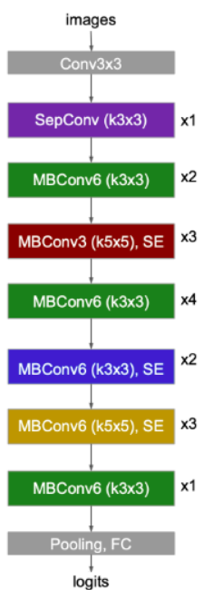

These are the Conv3x3 and SepConv blocks in the illustration. This is very similar to what MobileNet v2 does.

The next building block is called MBConv6. Again, this is pretty much the same as MobileNet v2:

1×1 expansion layer that increases the number of channels by a factor 6 3×3 depthwise conv 1×1 bottleneck layer that reduces the channels residual connection from the previous bottleneck layer (if it has the same number of channels)

The other buildings blocks in MnasNet are variations of the following:

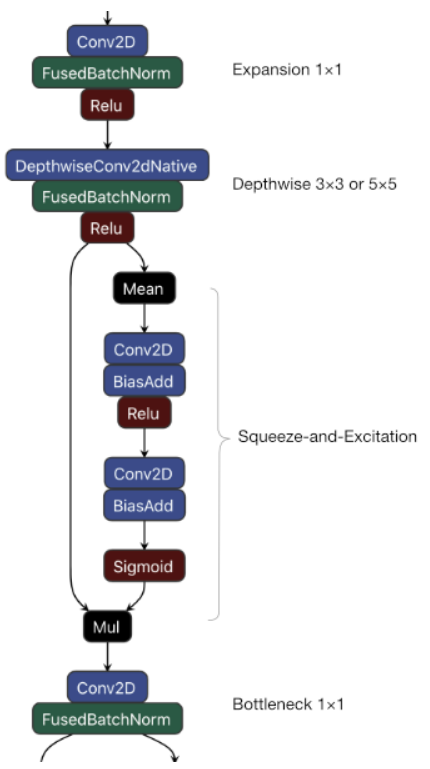

Again, this has an expansion layer, a depthwise convolution, and a bottleneck layer at the end (and possibly a residual connection to the previous bottleneck). In the MBConv3 blocks, the expansion layer uses a factor 3 instead of 6. Sometimes the depthwise convolution is 5×5 instead of 3×3.

The new thing is the addition of a squeeze-and-excitation (SE) module. The idea for this technique comes from the paper Squeeze-and-excitation networks.

Here’s what SE does: First, there is a global average pooling operation (the Mean layer in the illustration above) that reduces the spatial dimensions of the feature map to 1×1. If the feature map had dimensions H×W×C, it is now just a vector with C elements. This is the “squeeze”.

Next is the “excitation” part: This is performed by two 1×1 convolution layers with a non-linearity in between (ReLU in this case). The first conv layer massively reduces the number of channels by a factor of 12 or 24, the second conv layer increases the number of channels again to C. A sigmoid is applied to scale the results to be between 0 and 1.

The output of the SE branch is combined with the output from the depthwise layer through multiplication (the Mul layer in the illustration). This multiplication works on the channel dimension, and since the output of the sigmoid is between 0 and 1, this simply makes the activation values smaller in channels that are considered to be less important.

As the original paper says, “… the SE block learns how to weight the incoming feature maps.” This helps to increase the accuracy of the model and it’s pretty cheap because the SE layers are small.

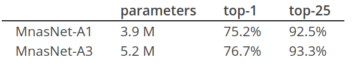

```python
# Batch norm is not used here due to some code issue .

def SE_layer(inp_tensor):
  x = Conv2D(64*3, (1,1), activation="relu", padding="same")(inp_tensor)
  x = DepthwiseConv2D((3,3) , activation='relu' , padding = 'same')(x)

  x1 = tf.math.reduce_mean(x ,  axis = [1 , 2] )
  x1 = tf.reshape(x1 ,  (-1, 1, 1 , 64*3))
  x1 = Conv2D((64*3)/12, (1,1), activation="relu", padding="same")(x1)
  x1 = Conv2D(64*3, (1,1), activation="sigmoid", padding="same")(x1)
  h ,  w , c = x.shape[1:]
  x1  = tf.broadcast_to(x1 , (-1 , h , w , c))

  x = Multiply()([x , x1])
  x = Conv2D(64 , (1,1) , padding = 'same')(x)

  return x
```

```python
inp_tensor = Input(shape = (32 ,32 ,64))
result = SE_layer(inp_tensor)
model =  Model(inp_tensor ,  result)
model.summary()
```

```
Model: "model_8"
__________________________________________________________________________________________________
Layer (type)                    Output Shape         Param #     Connected to
==================================================================================================
input_11 (InputLayer)           [(None, 32, 32, 64)] 0
__________________________________________________________________________________________________
conv2d_22 (Conv2D)              (None, 32, 32, 192)  12480       input_11[0][0]
__________________________________________________________________________________________________
depthwise_conv2d_10 (DepthwiseC (None, 32, 32, 192)  1920        conv2d_22[0][0]
__________________________________________________________________________________________________
tf.math.reduce_mean (TFOpLambda (None, 192)          0           depthwise_conv2d_10[0][0]
__________________________________________________________________________________________________
tf.reshape_2 (TFOpLambda)       (None, 1, 1, 192)    0           tf.math.reduce_mean[0][0]
__________________________________________________________________________________________________
conv2d_23 (Conv2D)              (None, 1, 1, 16)     3088        tf.reshape_2[0][0]
__________________________________________________________________________________________________
conv2d_24 (Conv2D)              (None, 1, 1, 192)    3264        conv2d_23[0][0]
__________________________________________________________________________________________________
tf.broadcast_to_2 (TFOpLambda)  (None, 32, 32, 192)  0           conv2d_24[0][0]
__________________________________________________________________________________________________
multiply_2 (Multiply)           (None, 32, 32, 192)  0           depthwise_conv2d_10[0][0]
                                                                 tf.broadcast_to_2[0][0]
__________________________________________________________________________________________________
conv2d_25 (Conv2D)              (None, 32, 32, 64)   12352       multiply_2[0][0]
==================================================================================================
Total params: 33,104
Trainable params: 33,104
Non-trainable params: 0
__________________________________________________________________________________________________
```

```python
tf.keras.utils.plot_model(
    model, to_file='tmp.png', show_shapes=True,
    show_layer_names=True, rankdir='LR', expand_nested=False, dpi=96
)
```

[figure not shown]

## Mobilenet v3 - 2019

The idea: Use MnasNet-A1 as the starting point but refine it using NetAdapt, an algorithm that automatically simplifies a pre-trained model until it reaches a given latency, while keeping accuracy high. They also made a number of improvements by hand.

The main changes are:

1. expensive layers were redesigned (the number of filters used by the expansion layers is different (the NetAdapt algorithm was used to find optimal values for these) )
2. use of **Swish** instead of ReLU6
3. squeeze-and-excitation modules (SE) . the squeeze-and-excitation (SE) modules only reduce the number of channels by a factor 3 or 4

MobileNet v1 and v2 both begin with a regular 3×3 convolution layer that has 32 filters. It turns out this is a relatively slow layer. It has only a few weights but it does need to work on a large 224×224 feature map. Experimentation showed that 16 filters is sufficient. ( most filters in earlier layer has close to zero weights , hence can be pruned. )

### Swish activation function :

$$ f(x) = x.sigmoid(x) $$

Experiments show that Swish tends to work better than ReLU on deeper models across a number of challenging data sets .

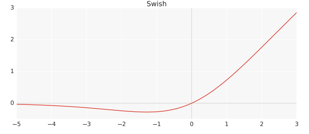

The simplicity of Swish and its similarity to ReLU make it easy for practitioners to replace ReLUs with Swish units in any neural network.

## Hard Swish

$$ hswish(x) = x*ReLU6(x + 3) / 6 $$

because sigmoid is expensive to compute, this is replaced by ReLU6. Clever trick, but only if you can do ReLU6 quickly…

Not all of the model uses h-swish: the first half of the layers use regular ReLU (except after the first conv layer). The MobileNet creators found that h-swish was only beneficial on the deeper layers. And because feature maps tend to be larger in the early layers, calculating their activations is more costly, so they chose to simply use ReLU (not ReLU6) on those layers as it is cheaper than h-swish.

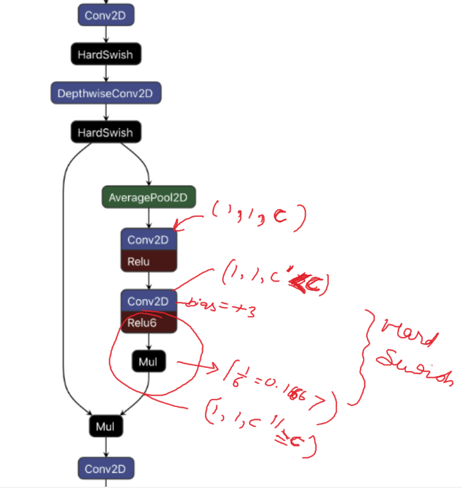

```python
from keras import backend as K
from keras.utils.generic_utils import get_custom_objects

def swish(x):
  return K.sigmoid(x) * x

def hard_swish(x):
  return x * K.relu(x + 3.0, max_value=6.0) / 6.0

# get_custom_objects().update({'swish': Activation(swish)})
# get_custom_objects().update({'hard_swish': Activation(hard_swish)})
```

```python
# Batch norm is not used here due to some code issue .

def mob3_SE_layer(inp_tensor):
  x = Conv2D(64*3, (1,1), activation=hard_swish, padding="same")(inp_tensor)
  x = DepthwiseConv2D((3,3) , activation=hard_swish , padding = 'same')(x)

  x1 = GlobalAveragePooling2D()(x)
  # x1 = tf.math.reduce_mean(x ,  axis = [1 , 2])
  x1 = tf.reshape(x1 ,  (-1, 1, 1 , 64*3))
  # channel reduction is only by a factor of 3 not 12 as in Mnasnet
  x1 = Conv2D((64*3)/3, (1,1), activation="relu", padding="same")(x1)
  x1 = Conv2D(64*3, (1,1), activation=hard_swish, padding="same")(x1)
  h ,  w , c = x.shape[1:]
  x1  = tf.broadcast_to(x1 , (-1 , h , w , c))

  x = Multiply()([x , x1])
  x = Conv2D(64 , (1,1) , padding = 'same')(x)

  return x
```

```python
inp_tensor = Input(shape = (32 ,32 ,64))
result = mob3_SE_layer(inp_tensor)
model =  Model(inp_tensor ,  result)
model.summary()
```

```
Model: "model_7"
__________________________________________________________________________________________________
Layer (type)                    Output Shape         Param #     Connected to
==================================================================================================
input_10 (InputLayer)           [(None, 32, 32, 64)] 0
__________________________________________________________________________________________________
conv2d_18 (Conv2D)              (None, 32, 32, 192)  12480       input_10[0][0]
__________________________________________________________________________________________________
depthwise_conv2d_9 (DepthwiseCo (None, 32, 32, 192)  1920        conv2d_18[0][0]
__________________________________________________________________________________________________
global_average_pooling2d_1 (Glo (None, 192)          0           depthwise_conv2d_9[0][0]
__________________________________________________________________________________________________
tf.reshape_1 (TFOpLambda)       (None, 1, 1, 192)    0           global_average_pooling2d_1[0][0]
__________________________________________________________________________________________________
conv2d_19 (Conv2D)              (None, 1, 1, 64)     12352       tf.reshape_1[0][0]
__________________________________________________________________________________________________
conv2d_20 (Conv2D)              (None, 1, 1, 192)    12480       conv2d_19[0][0]
__________________________________________________________________________________________________
tf.broadcast_to_1 (TFOpLambda)  (None, 32, 32, 192)  0           conv2d_20[0][0]
__________________________________________________________________________________________________
multiply_1 (Multiply)           (None, 32, 32, 192)  0           depthwise_conv2d_9[0][0]
                                                                 tf.broadcast_to_1[0][0]
__________________________________________________________________________________________________
conv2d_21 (Conv2D)              (None, 32, 32, 64)   12352       multiply_1[0][0]
==================================================================================================
Total params: 51,584
Trainable params: 51,584
Non-trainable params: 0
__________________________________________________________________________________________________
```

```python
tf.keras.utils.plot_model(
    model, to_file='tmp.png', show_shapes=True,
    show_layer_names=True, rankdir='LR', expand_nested=False, dpi=96
)
```

[figure not shown]

The final optimization involves the layers at the end.

In MobileNet v2, just before the global average pooling layer, is a 1×1 convolution that expands the number of channels from 320 to 1280, so that we have a lot of features that can be used by the classifier layer (or whatever else you stick on top of this backbone). But a big conv layer like that is also relatively slow compared to the rest of the model.

In MobileNet v3, this layer is placed behind the global average pooling layer so that it works on a much smaller feature map (1×1 instead of 7×7) and is therefore much faster. This small change also allows us to remove the previous bottleneck layer and depthwise filtering layer. In total they were able to remove three expensive layers with no loss in accuracy.

Here is an illustration of the model’s output stage:

[figure not shown]

## BlazeFace - 2019

BlazeFace is a face detection model from Google designed for mobile GPUs .

[figure not shown]

In the left branch is a depthwise separable convolution, just like in MobileNet v1. The right branch is a residual connection.

They made the following changes compared to MobileNet:

1. Increased the kernel size of the depthwise convolutions to 5×5. The rationale for this is that depthwise convolution is relatively cheap compared to the 1×1 convolution, so you might as well make it larger.
2. The residual connection is actually between the depthwise layers, not between bottleneck layers (as is done in MobileNet v2).
3. There is always a residual connection. If the number of channels changes due to the 1×1 convolution, a channel padding layer is added that simply appends empty feature maps to the back of the tensor.
4. Some of the depthwise layers have stride 2. When that happens, the residual branch also includes max pooling.
5. The activation function is regular ReLU (not ReLU6).

The BlazeFace feature extractor has 16 of these building blocks in a row. It’s a pretty simple architecture, which is why it is fast.

BlazeFace feature extractor only has 100k parameters and works on smallish 128×128 images

```python
from keras import backend as K

batch_size = 23

# This example shows stride = 2 version

def zeropad(x):
    y = tf.zeros(shape = (batch_size , x.shape[1] , x.shape[2] ,  6))
    return K.concatenate([x , y], axis=3)


def zeropad_output_shape(input_shape):
    shape = list(input_shape)
    shape[3] = 6
    assert len(shape) == 4
    return tuple(shape)


def blaze_face(inp_tensor):
  # Batch norm is not used here due to some code issue .
  x = DepthwiseConv2D((5,5) , padding = "same" , strides = (2,2))(inp_tensor)
  x = Conv2D(70 , (1,1))(x)
  print(x.shape)
  x1 = MaxPooling2D(pool_size = 2 ,  strides = (2,2) , padding = "same")(inp_tensor)
  x1 = Lambda(zeropad , output_shape=zeropad_output_shape)(x1)
  print(x1.shape)
  x2 = Add()([x , x1])
  x2 = Conv2D(64 , (1,1) )(x2)
  return x2
```

```python
inp_tensor = Input(shape = (32 ,32 ,64) ,batch_size = batch_size)
result = blaze_face(inp_tensor)
model =  Model(inp_tensor ,  result)
model.summary()
```

```
(23, 16, 16, 70)
(23, 16, 16, 70)
Model: "model_6"
__________________________________________________________________________________________________
Layer (type)                    Output Shape         Param #     Connected to
==================================================================================================
input_8 (InputLayer)            [(23, 32, 32, 64)]   0
__________________________________________________________________________________________________
depthwise_conv2d_7 (DepthwiseCo (23, 16, 16, 64)     1664        input_8[0][0]
__________________________________________________________________________________________________
max_pooling2d_7 (MaxPooling2D)  (23, 16, 16, 64)     0           input_8[0][0]
__________________________________________________________________________________________________
conv2d_13 (Conv2D)              (23, 16, 16, 70)     4550        depthwise_conv2d_7[0][0]
__________________________________________________________________________________________________
lambda_7 (Lambda)               (23, 16, 16, 70)     0           max_pooling2d_7[0][0]
__________________________________________________________________________________________________
add (Add)                       (23, 16, 16, 70)     0           conv2d_13[0][0]
                                                                 lambda_7[0][0]
__________________________________________________________________________________________________
conv2d_14 (Conv2D)              (23, 16, 16, 64)     4544        add[0][0]
==================================================================================================
Total params: 10,758
Trainable params: 10,758
Non-trainable params: 0
__________________________________________________________________________________________________
```

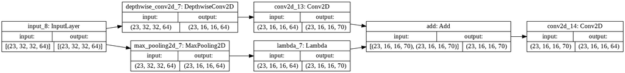

```python
tf.keras.utils.plot_model(
    model, to_file='tmp.png', show_shapes=True,
    show_layer_names=True, rankdir='LR', expand_nested=False, dpi=96
)
```

[figure not shown]

1. The first two layers are bottleneck layers, i.e. 1×1 convolutions that reduce the number of channels. If C is the number of input channels, the first bottleneck layer reduces this to C/2, the second one to C/4. As with the original SqueezeNet, these bottlenecks are used to cut back the number of parameters needed by the convolution layers that do the actual filtering. Why use two bottleneck layers in a row? Not sure, but perhaps this gives better results than going from C to C/4 in a single step. More layers is better!
2. Unlike the original SqueezeNet, there is no longer a 3×3 convolution. Instead, this has been split up into two smaller convolutions: 3×1 and 1×3. These both have C/2 filters. Splitting it into two smaller layers decreases the number of parameters needed. At the same time it increases the depth of the network, which generally improves the model. (Even more layers!)
1. The blocks in SqueezeNext are organized into four sections. In each new section, the spatial dimensions of the feature maps are halved. To achieve this, the very first bottleneck convolution has stride 2. Now the residual branch for that block must also have a stride 2 convolution, otherwise the outputs of both branches cannot be summed up.

The authors of SqueezeNext did not use depthwise separable convolutions on purpose, because these “do not give good performance on some embedded systems due to its low arithmetic intensity (ratio of compute to bandwidth).”

Interesting, because depthwise separable convolutions actually work very well on the iPhone GPU (see the success of MobileNet); the paper does not go into details about what sort of embedded systems they intended SqueezeNext for.

The very first layer in SqueezeNext is a 7×7 convolution with 64 filters and stride 2. This layer does not use zero-padding. It is immediately followed by max pooling, so the input size of 227×227 pixels is very quickly reduced to 55×55 pixels.

```python
batch_size = 23
def squeeze_block(inp_tensor):
  # Batch norm is not used here due to some code issue .
  c = inp_tensor.shape[-1]
  x = Conv2D(c/2 , (1,1) , padding="same")(inp_tensor)
  x = Conv2D(c/4 , (1,1) , padding="same")(x)
  x = Conv2D(c/2 , (3,1) , padding="same")(x)
  x = Conv2D(c/2 , (1,3) , padding="same")(x)
  x = Conv2D(c , (1,1) , padding="same")(x)
  x = Add()([x , inp_tensor])
  return x

def squeeze_block_stride(inp_tensor):
  # Batch norm is not used here due to some code issue .
  c = inp_tensor.shape[-1]
  x = Conv2D(c/2 , (1,1) , strides = (2,2))(inp_tensor)
  x = Conv2D(c/4 , (1,1) , padding="same")(x)
  x = Conv2D(c/2 , (3,1) , padding="same")(x)
  x = Conv2D(c/2 , (1,3) , padding="same")(x)
  x = Conv2D(c , (1,1) , padding="same")(x)

  x1 = Conv2D(c , (1,1) , strides = (2,2))(inp_tensor)
  x = Add()([x , x1])
  return x
```

```python
inp_tensor = Input(shape = (32 , 32 , 64) ,batch_size = batch_size)
result = squeeze_block_stride(inp_tensor)
model =  Model(inp_tensor ,  result)
model.summary()
```

```
Model: "model_2"
__________________________________________________________________________________________________
Layer (type)                    Output Shape         Param #     Connected to
==================================================================================================
input_6 (InputLayer)            [(23, 32, 32, 64)]   0
__________________________________________________________________________________________________
conv2d_21 (Conv2D)              (23, 16, 16, 32)     2080        input_6[0][0]
__________________________________________________________________________________________________
conv2d_22 (Conv2D)              (23, 16, 16, 16)     528         conv2d_21[0][0]
__________________________________________________________________________________________________
conv2d_23 (Conv2D)              (23, 16, 16, 32)     1568        conv2d_22[0][0]
__________________________________________________________________________________________________
conv2d_24 (Conv2D)              (23, 16, 16, 32)     3104        conv2d_23[0][0]
__________________________________________________________________________________________________
conv2d_25 (Conv2D)              (23, 16, 16, 64)     2112        conv2d_24[0][0]
__________________________________________________________________________________________________
conv2d_26 (Conv2D)              (23, 16, 16, 64)     4160        input_6[0][0]
__________________________________________________________________________________________________
add_4 (Add)                     (23, 16, 16, 64)     0           conv2d_25[0][0]
                                                                 conv2d_26[0][0]
==================================================================================================
Total params: 13,552
Trainable params: 13,552
Non-trainable params: 0
__________________________________________________________________________________________________
```

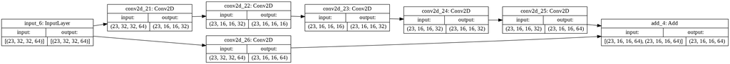

```python
tf.keras.utils.plot_model(
    model, to_file='tmp.png', show_shapes=True,
    show_layer_names=True, rankdir='LR', expand_nested=False, dpi=96
)
```

## ShuffleNet (2017 , 2018)

**The idea:** Many of the modern architectures use lots of dense 1×1 convolutions, also known as pointwise convolutions, but they can be relatively expensive. To bring down this cost, we can use group convolutions on those layers. But those have side effects, with can be mitigated using a channel shuffle operation.

A group-wise convolution divides the input feature maps into two or more groups in the channel dimension, and performs convolution separately on each group. It is the same as slicing the input into several feature maps of smaller depth, and then running a different convolution on each.

With two groups, you only need half the parameters because each convolution filter now works on half the input channels and produces half the output channels. (The weights are not shared between the groups — each group still learns its own parameters!)

A side effect of grouped convolution is that each output is only derived from a fraction of the inputs, i.e. the output channels are also divided into the same number of groups. This is not ideal because there is no information flow between different groups, which limits the network’s ability to learn interesting things.

The solution is simple: just shuffle things around a bit afterwards.

**Group convolution is similar to depthwise convolution. In fact, depthwise convolution is sometimes implemented using the more general grouped convolution.**

[figure not shown]

**shuffleNet V1**

[figure not shown]

1. The first convolution is a 1×1 bottleneck layer that reduces the number of channels by a factor of 4. This layer uses grouped convolution and is followed by channel shuffle.
2. The 3×3 layer is a depthwise convolution with batchnorm but without ReLU. Not using ReLU gave better results here.
3. The final layer is another 1×1 grouped convolution, which is used to expand the number of channels again (to match those of the residual connection). On this layer there is no channel shuffle as the authors found it didn’t make any difference in that spot.
4. As usual, there is a residual connection.
5. Sometimes the depthwise layer will have stride , In that case, the left branch has a 3×3 average pooling layer inside it and the results are concatenated with the main branch, not added.

```python
batch_size = 23

def  channel_shuffle(x):
  g = 2
  b , h , w , c = x.shape
  x = tf.reshape(x , shape = (b  ,h , w , g , c//g))
  x = tf.transpose(x ,  perm  = (0 , 1 , 2, 4 ,3))
  x = tf.reshape(x ,  shape = (b ,h ,w ,c))
  return x


def shuffle_net1(inp_tensor):
  print(inp_tensor.shape)
  c = inp_tensor.shape[-1]
  x1 = Lambda(lambda x : x[: , : , : ,:c//2])(inp_tensor)
  x1 = BatchNormalization()(x1)
  x1 = Conv2D(16 , (1,1) , padding = 'same')(x1)

  x2 = Lambda(lambda x : x[: , : , : ,c//2:])(inp_tensor)
  x2 = BatchNormalization()(x2)
  x2 = Conv2D(16 , (1,1) , padding = 'same')(x2)

  x =  Concatenate()([x1 , x2])

  x = Lambda(channel_shuffle)(x)
  x = DepthwiseConv2D((3,3) , padding = "same")(x)
  x = BatchNormalization()(x)

  c = x.shape[-1]
  x1 = Lambda(lambda x : x[: , : , : ,:c//2])(x)
  x1 = BatchNormalization()(x1)
  x1 = Conv2D(32 , (1,1) , padding = 'same')(x1)

  x2 = Lambda(lambda x : x[: , : , : ,c//2:])(x)
  x2 = BatchNormalization()(x2)
  x2 = Conv2D(32 , (1,1) , padding = 'same')(x2)

  x =  Concatenate()([x1 , x2])
  x = BatchNormalization()(x)

  print(x.shape)
  x = Add()([x , inp_tensor])
  x = Activation('relu')(x)

  return x

inp_tensor = Input(shape = (32 , 32 , 64) ,batch_size = batch_size)
result = shuffle_net1(inp_tensor)
model =  Model(inp_tensor ,  result)
model.summary()
```

```
(23, 32, 32, 64)
(23, 32, 32, 64)
Model: "model_2"
__________________________________________________________________________________________________
Layer (type)                    Output Shape         Param #     Connected to
==================================================================================================
input_26 (InputLayer)           [(23, 32, 32, 64)]   0
__________________________________________________________________________________________________
lambda_32 (Lambda)              (23, 32, 32, 32)     0           input_26[0][0]
__________________________________________________________________________________________________
lambda_33 (Lambda)              (23, 32, 32, 32)     0           input_26[0][0]
__________________________________________________________________________________________________
batch_normalization_16 (BatchNo (23, 32, 32, 32)     128         lambda_32[0][0]
__________________________________________________________________________________________________
batch_normalization_17 (BatchNo (23, 32, 32, 32)     128         lambda_33[0][0]
__________________________________________________________________________________________________
conv2d_26 (Conv2D)              (23, 32, 32, 16)     528         batch_normalization_16[0][0]
__________________________________________________________________________________________________
conv2d_27 (Conv2D)              (23, 32, 32, 16)     528         batch_normalization_17[0][0]
__________________________________________________________________________________________________
concatenate_7 (Concatenate)     (23, 32, 32, 32)     0           conv2d_26[0][0]
                                                                 conv2d_27[0][0]
__________________________________________________________________________________________________
lambda_34 (Lambda)              (23, 32, 32, 32)     0           concatenate_7[0][0]
__________________________________________________________________________________________________
depthwise_conv2d_1 (DepthwiseCo (23, 32, 32, 32)     320         lambda_34[0][0]
__________________________________________________________________________________________________
batch_normalization_18 (BatchNo (23, 32, 32, 32)     128         depthwise_conv2d_1[0][0]
__________________________________________________________________________________________________
lambda_35 (Lambda)              (23, 32, 32, 16)     0           batch_normalization_18[0][0]
__________________________________________________________________________________________________
lambda_36 (Lambda)              (23, 32, 32, 16)     0           batch_normalization_18[0][0]
__________________________________________________________________________________________________
batch_normalization_19 (BatchNo (23, 32, 32, 16)     64          lambda_35[0][0]
__________________________________________________________________________________________________
batch_normalization_20 (BatchNo (23, 32, 32, 16)     64          lambda_36[0][0]
__________________________________________________________________________________________________
conv2d_28 (Conv2D)              (23, 32, 32, 32)     544         batch_normalization_19[0][0]
__________________________________________________________________________________________________
conv2d_29 (Conv2D)              (23, 32, 32, 32)     544         batch_normalization_20[0][0]
__________________________________________________________________________________________________
concatenate_8 (Concatenate)     (23, 32, 32, 64)     0           conv2d_28[0][0]
                                                                 conv2d_29[0][0]
__________________________________________________________________________________________________
batch_normalization_21 (BatchNo (23, 32, 32, 64)     256         concatenate_8[0][0]
__________________________________________________________________________________________________
add_9 (Add)                     (23, 32, 32, 64)     0           batch_normalization_21[0][0]
                                                                 input_26[0][0]
__________________________________________________________________________________________________
activation_1 (Activation)       (23, 32, 32, 64)     0           add_9[0][0]
==================================================================================================
Total params: 3,232
Trainable params: 2,848
Non-trainable params: 384
__________________________________________________________________________________________________
```

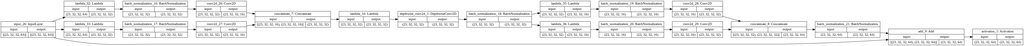

```python
tf.keras.utils.plot_model(
    model, to_file='tmp.png', show_shapes=True,
    show_layer_names=True, rankdir='LR', expand_nested=False, dpi=96
)
```

```python
## Pseudo example of channel shuffling
c = tf.constant([1 ,1 ,1, 0, 0, 0])
print(c)
c = tf.reshape(c , shape = (1, 2, 3))
c = tf.transpose(c)
print(c)
c = tf.reshape(c ,  shape = (1, 3 , 2))
print(c)
c = tf.reshape(c , shape = (6))
c
```

```
tf.Tensor([1 1 1 0 0 0], shape=(6,), dtype=int32)
tf.Tensor(
[[[1]
  [0]]

 [[1]
  [0]]

 [[1]
  [0]]], shape=(3, 2, 1), dtype=int32)
tf.Tensor(
[[[1 0]
  [1 0]
  [1 0]]], shape=(1, 3, 2), dtype=int32)
```

```
<tf.Tensor: shape=(6,), dtype=int32, numpy=array([1, 0, 1, 0, 1, 0], dtype=int32)>
```

### Shufflenet v2

[figure not shown]

Here’s what changed:

1. To replace the group convolutions( due to high memory read/write ), there is a new channel split operation, which sends half the channels through the left branch and the other half through the right branch — this is like using two groups.
2. The 1×1 convolutions are no longer groupwise.
3. The convolutions now always have the same number of input and output channels. They found that, when the number of channels stays the same, the amount of memory accesses in the convolution is optimal.
4. The shortcut connection is now always concatenated( addition are relatively expensive — they perform a lot of memory accesses but do little computation ) , not summed — this is the reverse operation of the channel split at the beginning. (So, technically speaking it’s no longer a residual connection.) The channel shuffle is still there but has moved to the end.

**CONCLUSION** : ShuffleNet v1 is on-par with Mobilenet v1 (0.75 depth multiplier).

ShuffleNet v2 with 1.0 scale factor is a bit better than ShuffleNet v1. (The scale factor is like the depth multiplier used in other models. It increases or decreases the number of filters used by the convolution layers throughout the network.)

ShuffleNet v2 with 1.5 scale factor is comparable with MobileNet v2, even slightly better.

**The accuracy scores are among the best we’ve seen so far in this blog post. They’re generally better than MobileNet at the same number of parameters.**

## CondenseNet 2017

**The idea:** Like ShuffleNet v1, use group convolutions for 1×1 layers, but learn the groupings.

The starting point is an architecture similar to DenseNet, where each layer’s output is concatenated with the outputs of all the layers before it. Reusing the features in this way helps to boost accuracy.

However, this kind of dense connectivity may be more than we need, as features from early layers may not always be needed in later layers. The problem, of course, is that you don’t know beforehand which features should be reused.

This is where CondenseNet comes in: during training it learns which features from earlier layers are important enough to keep.

It does this by splitting up the filters from a convolution layer into groups, typically 4 or 8 groups per layer.

Over time, input features that are considered less important are pruned from the model. This is done per group, so a given input feature can be removed from one group of filters but still be used by another group.

When training is done, each group in this layer only keeps 1/C of the original filters where C is known as the condensation factor. C is typically 4 or 8.

At inference time, we don’t have to worry about any of this. However, we do need to ignore feature maps coming from earlier layers that have been pruned away.

## ESPNet 2018